# Assignment4_Q3

2024-05-26

```r
# Load necessary libraries
library(qicharts2)
library(dplyr)
library(lubridate)
# Read the CSV file
data <- read.csv("monitor.csv", header = TRUE, stringsAsFactors = FALSE)
```

```r
# Convert Timestamp to Date object and add Day of the Year
data$Timestamp <- as.POSIXct(data$Timestamp, format = "%Y-%m-%d %H:%M:%S")
data$DayOfYear <- yday(data$Timestamp)
data
```

```
##                 Timestamp ProcessMemory Prediction PredictionTimeMS DayOfYear
## 1     2021-02-01 13:12:23      8.885966   45.16977        155.33868        32
## 2     2021-02-01 13:16:23      9.461315   42.73333        284.69148        32
## 3     2021-02-01 13:22:43      9.039423   55.62624        421.84930        32
## 4     2021-02-01 13:22:51      9.069385   69.66720        468.25845        32
## 5     2021-02-01 13:37:31      8.077003   59.94067        451.43114        32
## 6     2021-02-01 13:49:22      8.512775   62.24831        384.21619        32
## 7     2021-02-01 14:11:35      9.456624   51.49203        349.56806        32
## 8     2021-02-01 14:15:47      8.988867   68.99997        311.84349        32
## 9     2021-02-01 14:20:44      8.861443   53.66074        375.29264        32
## 10    2021-02-01 14:24:28      9.046725   49.70113        328.78800        32
## 11    2021-02-01 14:27:03      8.854238   68.02711        363.50238        32
## 12    2021-02-01 14:35:21      8.252418   45.69165        456.01781        32
## 13    2021-02-01 14:40:26      9.671493   62.85238        485.48241        32
## 14    2021-02-01 14:41:44      8.444138   48.11630        280.45298        32
```

[output cut: 16055 more lines]

The data is started from 1st February 2021, so the DayOfYear column starts withe the value of 32.

## a) Is the memory usage of the server in control?

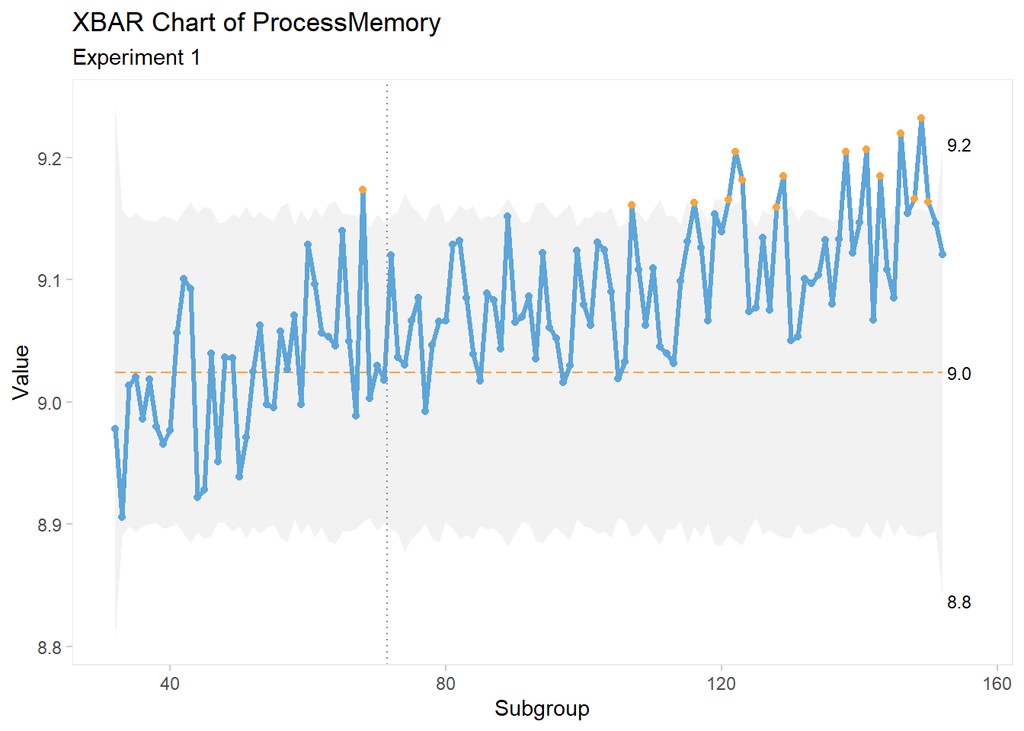

```r
a <- qicharts2::qic(x = DayOfYear, y = ProcessMemory, data = data, chart = "xbar", subtitle = "Experiment 1",freeze = 40)
plot(a)
```

```r
summary(a)
```

```
##   facet1 facet2 part n.obs n.useful longest.run longest.run.max n.crossings
## 1      1      1    1   121      121          47              10          25
##   n.crossings.min runs.signal    aLCL aLCL.95       CL  aUCL.95     aUCL
## 1              51           1 8.89263 8.93647 9.024152 9.111834 9.155675
##   sigma.signal
## 1           15
```

```r
summary(a) %>%
  select(runs.signal, sigma.signal)
```

```
##   runs.signal sigma.signal
## 1           1           15
```

The run.signal = 1 and sigma.signal=15 of this xbar chart summary suggests that the mean has a problem.

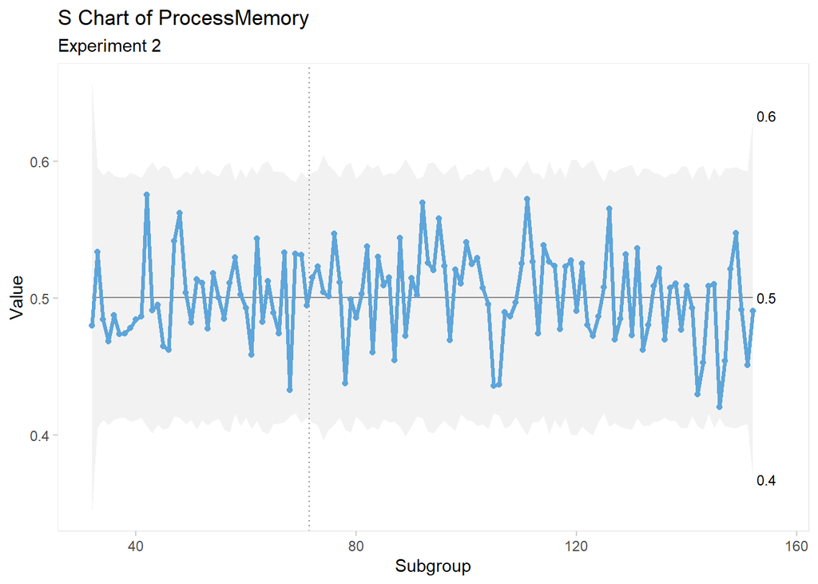

```r
b <- qicharts2::qic(x = DayOfYear, y = ProcessMemory, data = data, chart = "s", subtitle = "Experiment 2",freeze = 40)
plot(b)
```

```r
summary(b)
```

```
##   facet1 facet2 part n.obs n.useful longest.run longest.run.max n.crossings
## 1      1      1    1   121      121           8              10          56
##   n.crossings.min runs.signal      aLCL   aLCL.95        CL   aUCL.95      aUCL
## 1              51           0 0.4072098 0.4383012 0.5004841 0.5626669 0.5937584
##   sigma.signal
## 1            0
```

```r
summary(b) %>%
  select(runs.signal, sigma.signal)
```

```
##   runs.signal sigma.signal
## 1           0            0
```

The run.signal = 0 and sigma.signal=0 of this S chart summary suggests that the standard deviation doesn’t have a problem.

From the analysis of these plots, we can conclude that there is a noticeable drift in the mean, while the spread(standard deviation) remains stable. This indicates that the memory usage on the server is **not in control**.

## b) Is the prediction time of the model in control?

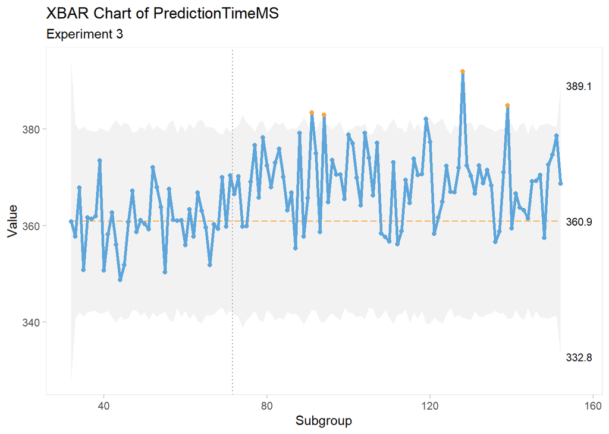

```r
aa <- qicharts2::qic(x = DayOfYear, y = PredictionTimeMS, data = data, chart = "xbar", subtitle = "Experiment 3",freeze = 40)
plot(aa)
```

```r
summary(aa)
```

```
##   facet1 facet2 part n.obs n.useful longest.run longest.run.max n.crossings
## 1      1      1    1   121      121          14              10          41
##   n.crossings.min runs.signal     aLCL  aLCL.95       CL  aUCL.95     aUCL
## 1              51           1 341.1217 347.7209 360.9193 374.1177 380.7169
##   sigma.signal
## 1            4
```

```r
summary(aa) %>%
  select(runs.signal, sigma.signal)
```

```
##   runs.signal sigma.signal
## 1           1            4
```

The run.signal = 1 and sigma.signal=4 of this xbar chart summary suggests that the mean has a problem.

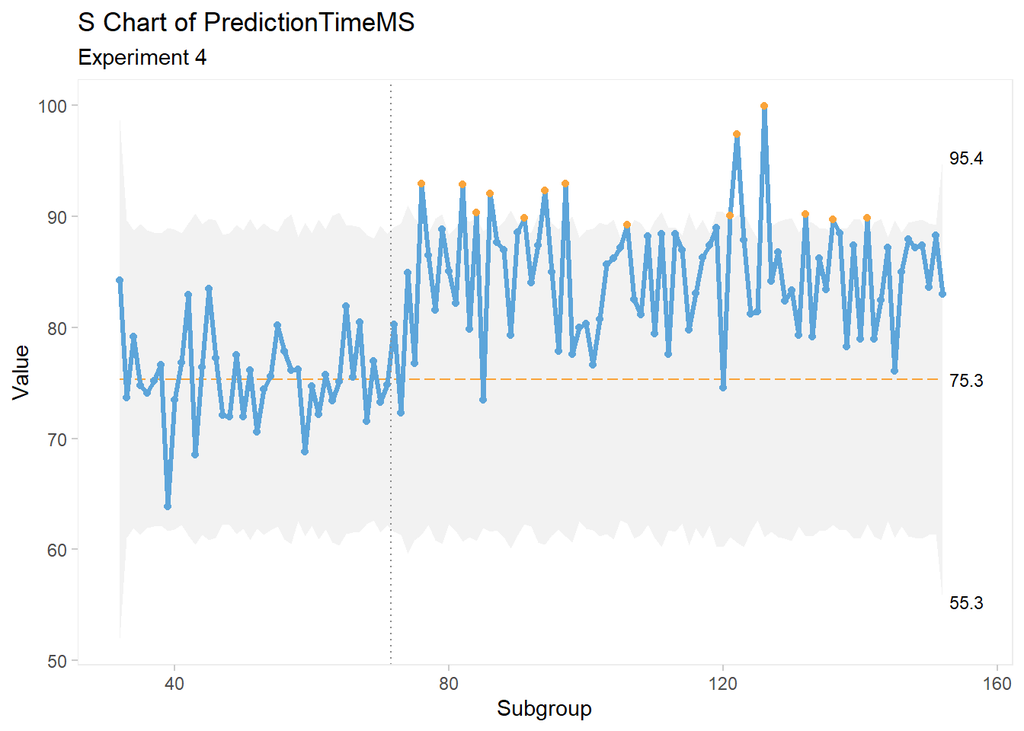

```r
bb <- qicharts2::qic(x = DayOfYear, y = PredictionTimeMS, data = data, chart = "s", subtitle = "Experiment 4",freeze = 40)
plot(bb)
```

```r
summary(bb)
```

```
##   facet1 facet2 part n.obs n.useful longest.run longest.run.max n.crossings
## 1      1      1    1   121      121          34              10          28
##   n.crossings.min runs.signal     aLCL  aLCL.95       CL  aUCL.95     aUCL
## 1              51           1 61.29564 65.97571 75.33584 84.69597 89.37603
##   sigma.signal
## 1           14
```

```r
summary(bb) %>%
  select(runs.signal, sigma.signal)
```

```
##   runs.signal sigma.signal
## 1           1           14
```

The run.signal = 1 and sigma.signal=14 of this S chart summary suggests that the standard deviation has a problem.

From the analysis of these plots, we can conclude that there is a noticeable drift in the mean, and a noticeable drift in the spread(standard deviation) . This indicates that the prediction time of the model is **not in control**.

## c) Is the stream of predictions in control?

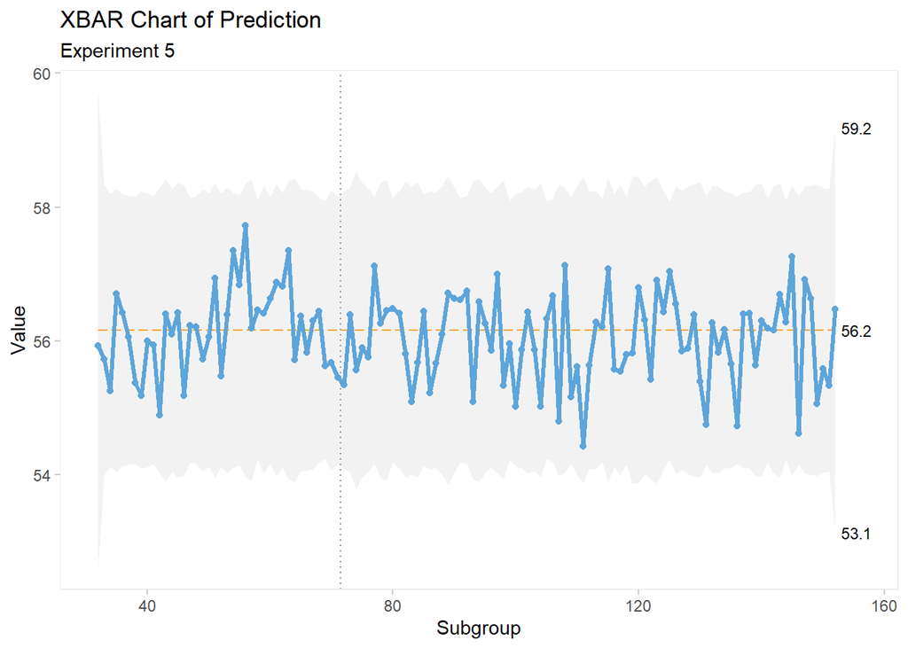

```r
aaa <- qicharts2::qic(x = DayOfYear, y = Prediction, data = data, chart = "xbar", subtitle = "Experiment 5",freeze = 40)
plot(aaa)
```

```r
summary(aaa)
```

```
##   facet1 facet2 part n.obs n.useful longest.run longest.run.max n.crossings
## 1      1      1    1   121      121          11              10          55
##   n.crossings.min runs.signal    aLCL  aLCL.95       CL  aUCL.95     aUCL
## 1              51           1 54.0339 54.74312 56.16157 57.58002 58.28925
##   sigma.signal
## 1            0
```

```r
summary(aaa) %>%
  select(runs.signal, sigma.signal)
```

```
##   runs.signal sigma.signal
## 1           1            0
```

The run.signal = 1 and sigma.signal=0 of this xbar chart summary suggests that the mean has a problem. Here although the points are within the range, there is one instance where the longest run is greater than the longest run max.

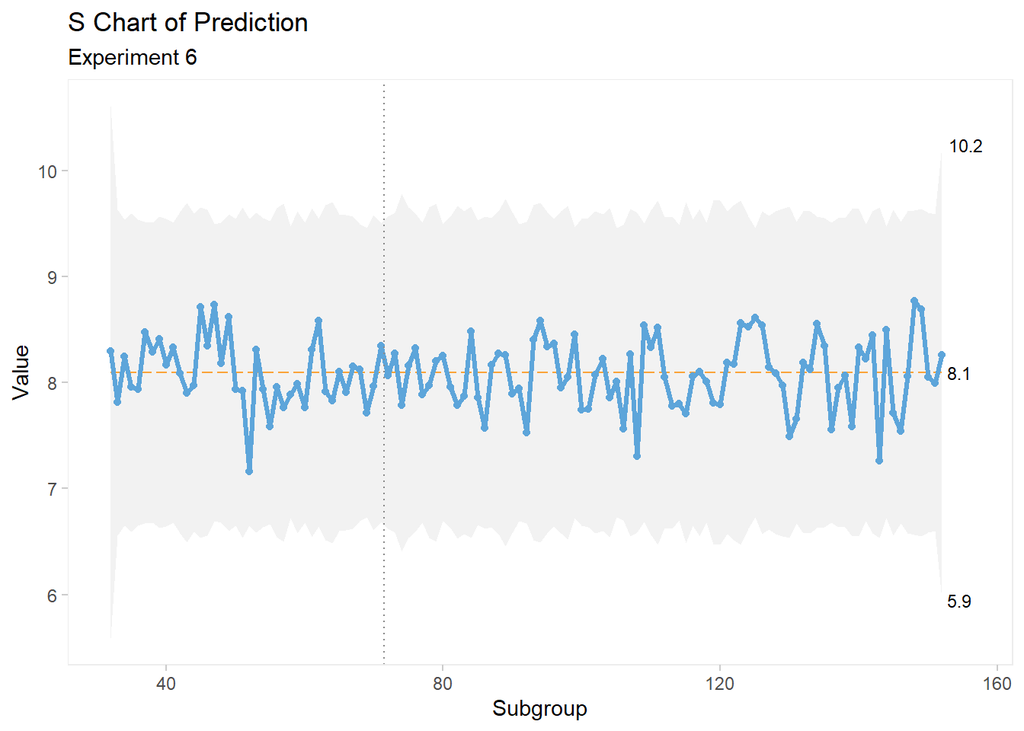

```r
bbb <- qicharts2::qic(x = DayOfYear, y = Prediction, data = data, chart = "s", subtitle = "Experiment 6",freeze = 40)
plot(bbb)
```

```r
summary(bbb)
```

```
##   facet1 facet2 part n.obs n.useful longest.run longest.run.max n.crossings
## 1      1      1    1   121      121           7              10          50
##   n.crossings.min runs.signal     aLCL  aLCL.95       CL aUCL.95     aUCL
## 1              51           1 6.587532 7.090506 8.096453  9.1024 9.605373
##   sigma.signal
## 1            0
```

```r
summary(bbb) %>%
  select(runs.signal, sigma.signal)
```

```
##   runs.signal sigma.signal
## 1           1            0
```

The run.signal = 1 and sigma.signal=0 of this S chart summary suggests that the standard deviation has a problem. Here, although the points are within the range, there is one instance where the number of crossings are less than the minimum number of crossing value.